# Intro to Data Science - HW 10

##### Copyright 2021, Jeffrey Stanton, Jeffrey Saltz, and Jasmina Tacheva

```r
# Rutwik Ghag
```

### Attribution statement: (choose only one and delete the rest)

```r
# 1. I did this homework by myself, with help from the book and the professor.
```

**Association mining** can be applied to many data problems beyond the well-known example of **finding relationships between different products in customer shopping data**. In this homework assignment, we will explore **real data** from the banking sector and look for **patterns associated with the likelihood of responding positively to a direct marketing campaign and signing up for a term deposit with the bank (stored in the variable “y”)**.  
You can find out more about the variables in this dataset here: https://archive.ics.uci.edu/ml/datasets/bank+marketing

## Part 1: Explore Data Set

1. Read the contents of the following URL to a dataframe called **bank**  
   https://intro-datascience.s3.us-east-2.amazonaws.com/bank-full.csv

**Hint**: Even though this is a .csv file, chances are R won’t be able to read it in correctly using the read_csv() function. If you take a closer look at the contents of the URL file, you may notice each field is separated by a **semicolon** (;) rather than a comma.

In situations like this, consider using either read.csv or read.table, with two additional parameters. *sep=“;”* defines how the data is seperated (the default is a comma), and *header=TRUE* defines that there is a header line in the dataset.

```r
urll <- 'https://intro-datascience.s3.us-east-2.amazonaws.com/bank-full.csv'
bank <- read.csv(urll, sep = ";",header = TRUE)
```

Make sure there are **41,188** rows and **21** columns in your **bank** df.

```r
summary(bank)
```

```
##       age            job              marital           education
##  Min.   :17.00   Length:41188       Length:41188       Length:41188
##  1st Qu.:32.00   Class :character   Class :character   Class :character
##  Median :38.00   Mode  :character   Mode  :character   Mode  :character
##  Mean   :40.02
##  3rd Qu.:47.00
##  Max.   :98.00
##    default            housing              loan             contact
##  Length:41188       Length:41188       Length:41188       Length:41188
##  Class :character   Class :character   Class :character   Class :character
##  Mode  :character   Mode  :character   Mode  :character   Mode  :character
##
##
##
##     month           day_of_week           duration         campaign
##  Length:41188       Length:41188       Min.   :   0.0   Min.   : 1.000
##  Class :character   Class :character   1st Qu.: 102.0   1st Qu.: 1.000
##  Mode  :character   Mode  :character   Median : 180.0   Median : 2.000
##                                        Mean   : 258.3   Mean   : 2.568
##                                        3rd Qu.: 319.0   3rd Qu.: 3.000
##                                        Max.   :4918.0   Max.   :56.000
##      pdays          previous       poutcome          emp.var.rate
##  Min.   :  0.0   Min.   :0.000   Length:41188       Min.   :-3.40000
##  1st Qu.:999.0   1st Qu.:0.000   Class :character   1st Qu.:-1.80000
##  Median :999.0   Median :0.000   Mode  :character   Median : 1.10000
##  Mean   :962.5   Mean   :0.173                      Mean   : 0.08189
##  3rd Qu.:999.0   3rd Qu.:0.000                      3rd Qu.: 1.40000
##  Max.   :999.0   Max.   :7.000                      Max.   : 1.40000
##  cons.price.idx  cons.conf.idx     euribor3m      nr.employed
##  Min.   :92.20   Min.   :-50.8   Min.   :0.634   Min.   :4964
##  1st Qu.:93.08   1st Qu.:-42.7   1st Qu.:1.344   1st Qu.:5099
##  Median :93.75   Median :-41.8   Median :4.857   Median :5191
##  Mean   :93.58   Mean   :-40.5   Mean   :3.621   Mean   :5167
##  3rd Qu.:93.99   3rd Qu.:-36.4   3rd Qu.:4.961   3rd Qu.:5228
##  Max.   :94.77   Max.   :-26.9   Max.   :5.045   Max.   :5228
##       y
##  Length:41188
##  Class :character
##  Mode  :character
##
##
##
```

```r
nrow(bank)
```

```
## [1] 41188
```

```r
ncol(bank)
```

```
## [1] 21
```

```r
# we used nrow and ncol to find the number of rows and columns
```

2. Next, we will focus on some key factor variables from the dataset, and convert a few numeric ones to factor variables. Execute the following command. Write a comment describing how the conversion for each numeric variable works and what are the variables in the resulting dataframe.

```r
bank_new <- data.frame(job=as.factor(bank$job),
                     marital=as.factor(bank$marital),
                     housing_loan=as.factor(bank$housing),
                     young=as.factor(bank$age<median(bank$age)),
                     contacted_more_than_once=as.factor(bank$campaign>1),
                     contacted_before_this_campaign=as.factor(bank$previous<0),
                     success=as.factor(bank$y))
```

3. Count the number of successful term deposit sign-ups, using the table( ) command on the **success** variable.

```r
table(bank_new$success)
```

```
##
##    no   yes
## 36548  4640
```

```r
# number of successful term deposits are 4640
```

4. Express the results of problem C as percentages by sending the results of the table( ) command into the prop.table( ) command.

```r
dim(table(bank_new$success))
```

```
## [1] 2
```

```r
prop.table(table(bank_new$success))*100
```

```
##
##       no      yes
## 88.73458 11.26542
```

```r
proportions(table(bank_new$success))*100
```

```
##
##       no      yes
## 88.73458 11.26542
```

5. Using the same techniques, show the percentages for the **marital** and **housing_loan** variables as well.

```r
# multiplying by 100 to express the percentage from the proportions
proportions(table(bank_new$marital))*100
```

```
##
##   divorced    married     single    unknown
## 11.1974361 60.5224823 28.0858502  0.1942313
```

```r
proportions(table(bank_new$housing_loan))*100
```

```
##
##        no   unknown       yes
## 45.212198  2.403613 52.384190
```

## Part 2: Coerce the data frame into transactions

6. Install and library two packages: **arules** and **arulesViz**.

```r
#install.packages("arules")
library(arules)
```

```r
#install.packages("arulesViz")
library(arulesViz)
```

7. Coerce the **bank_new** dataframe into a **sparse transactions matrix** called **bankX**.

```r
bankX <- as(bank_new,"transactions")
summary(bankX)
```

```
## transactions as itemMatrix in sparse format with
##  41188 rows (elements/itemsets/transactions) and
##  26 columns (items) and a density of 0.2692308
##
## most frequent items:
## contacted_before_this_campaign=FALSE                           success=no
##                                41188                                36548
##                      marital=married        contacted_more_than_once=TRUE
##                                24928                                23546
##                     housing_loan=yes                              (Other)
##                                21576                               140530
##
## element (itemset/transaction) length distribution:
## sizes
##     7
## 41188
##
##    Min. 1st Qu.  Median    Mean 3rd Qu.    Max.
##       7       7       7       7       7       7
##
## includes extended item information - examples:
##             labels variables       levels
## 1       job=admin.       job       admin.
## 2  job=blue-collar       job  blue-collar
## 3 job=entrepreneur       job entrepreneur
##
## includes extended transaction information - examples:
##   transactionID
## 1             1
## 2             2
## 3             3
```

8. Use the itemFrequency( ) and itemFrequencyPlot( ) commands to explore the contents of **bankX**. What do you see?

```r
itemFrequency(bankX)
```

```
##                           job=admin.                      job=blue-collar
##                          0.253034865                          0.224677090
##                     job=entrepreneur                        job=housemaid
##                          0.035350102                          0.025735651
##                       job=management                          job=retired
##                          0.070991551                          0.041759736
##                    job=self-employed                         job=services
##                          0.034500340                          0.096363018
##                          job=student                       job=technician
##                          0.021244052                          0.163712732
##                       job=unemployed                          job=unknown
##                          0.024618821                          0.008012042
##                     marital=divorced                      marital=married
##                          0.111974361                          0.605224823
##                       marital=single                      marital=unknown
##                          0.280858502                          0.001942313
##                      housing_loan=no                 housing_loan=unknown
##                          0.452121977                          0.024036127
##                     housing_loan=yes                          young=FALSE
##                          0.523841896                          0.520054385
##                           young=TRUE       contacted_more_than_once=FALSE
##                          0.479945615                          0.428328639
##        contacted_more_than_once=TRUE contacted_before_this_campaign=FALSE
##                          0.571671361                          1.000000000
##                           success=no                          success=yes
##                          0.887345829                          0.112654171
```

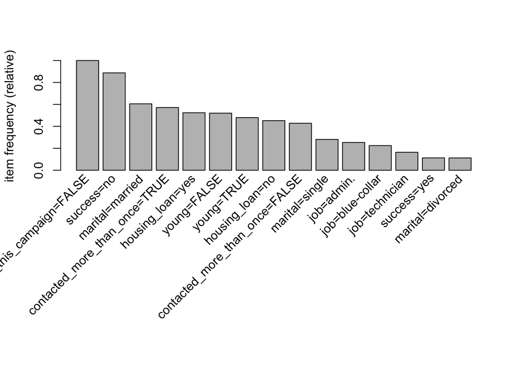

```r
# In the item frequency plot I see frequency of items in a particular column as a proportion of the total number of items present in that respective column

itemFrequencyPlot(bankX,topN = 15)
```

```r
# Now When we plot them we get the same thing but in an ordered way in which the highest frequency is at the left most side. The number 15 shows the top 15 frequencies histogram graphs
```

1. This is a fairly large dataset, so we will explore only the first 10 observations in the **bankX** transaction matrix:

```r
inspect(bankX[1:10])
```

```
##      items                                   transactionID
## [1]  {job=housemaid,
##       marital=married,
##       housing_loan=no,
##       young=FALSE,
##       contacted_more_than_once=FALSE,
##       contacted_before_this_campaign=FALSE,
##       success=no}                                       1
## [2]  {job=services,
##       marital=married,
##       housing_loan=no,
##       young=FALSE,
##       contacted_more_than_once=FALSE,
##       contacted_before_this_campaign=FALSE,
##       success=no}                                       2
## [3]  {job=services,
##       marital=married,
##       housing_loan=yes,
##       young=TRUE,
##       contacted_more_than_once=FALSE,
##       contacted_before_this_campaign=FALSE,
##       success=no}                                       3
## [4]  {job=admin.,
##       marital=married,
##       housing_loan=no,
##       young=FALSE,
##       contacted_more_than_once=FALSE,
##       contacted_before_this_campaign=FALSE,
##       success=no}                                       4
## [5]  {job=services,
##       marital=married,
##       housing_loan=no,
##       young=FALSE,
##       contacted_more_than_once=FALSE,
##       contacted_before_this_campaign=FALSE,
##       success=no}                                       5
## [6]  {job=services,
##       marital=married,
##       housing_loan=no,
##       young=FALSE,
```

[output cut: 16 more lines]

```
##       success=no}                                       8
## [9]  {job=technician,
##       marital=single,
##       housing_loan=yes,
##       young=TRUE,
##       contacted_more_than_once=FALSE,
##       contacted_before_this_campaign=FALSE,
##       success=no}                                       9
## [10] {job=services,
##       marital=single,
##       housing_loan=yes,
##       young=TRUE,
##       contacted_more_than_once=FALSE,
##       contacted_before_this_campaign=FALSE,
##       success=no}                                       10
```

Explain the difference between **bank_new** and **bankX** in a block comment:

```r
#install.packages("XQuartz")
View(bank_new)
#View(bankX)
summary(bank_new)
```

```
##           job            marital       housing_loan     young
##  admin.     :10422   divorced: 4612   no     :18622   FALSE:21420
##  blue-collar: 9254   married :24928   unknown:  990   TRUE :19768
##  technician : 6743   single  :11568   yes    :21576
##  services   : 3969   unknown :   80
##  management : 2924
##  retired    : 1720
##  (Other)    : 6156
##  contacted_more_than_once contacted_before_this_campaign success
##  FALSE:17642              FALSE:41188                    no :36548
##  TRUE :23546                                             yes: 4640
##
##
##
##
##
```

```r
#summary(bankX)

# bankX is a sparse transaction matrix whereas bank_new is the dataframe. Though the data might be same in bankX and bank_new since bank_new was created from the columns of bank but first converting them in factor values, how the values are represented is different. Using summary in them shows us the different way of representation gives us different analysis. When using View we can see that bankX is more like an object whereas bank_new is a databa se with entries
```